# tmplate

- **Name**: `Unpacking`
- **Fully Qualified Name**: `org.openprovenance.templates.physical.Unpacking`
- **IRI**: https://openprovenance.org/templates/org/openprovenance/templates/physical/Unpacking
- **Purpose**: The template `Unpacking` describes the evolution of a container as an item is removed from it.
- **Context**: The template helps describe common situations in the physical world involving containers such as boxes, pallets, etc.
- **Design considerations**: The ability to describe the state of the container (before and after inserting an item) and the state of the item (before being in the container or after).
- **Automation**: ttfs/config-unpacking.json

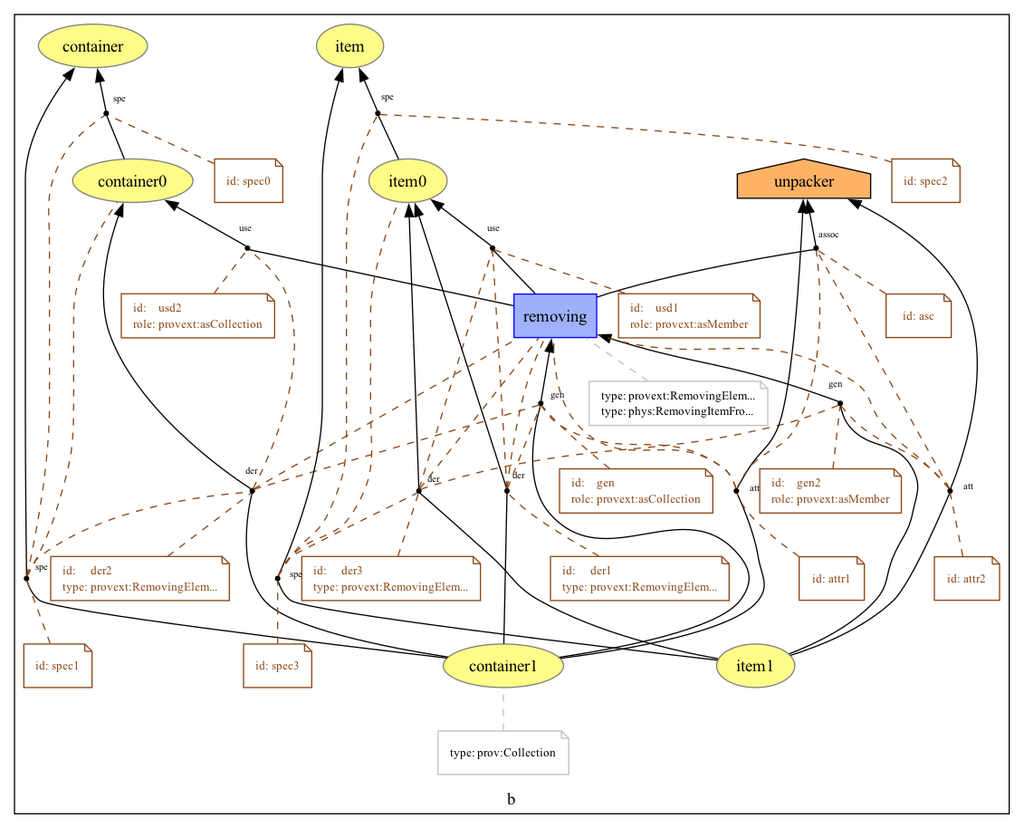

Figure 1: org.openprovenance.templates.physical.Unpacking

- **Details**:

  This template is a refinement of `org.openprovenance.templates.collections.RemovingFromCollection` where the collection is a physical container, and the item is physical. At the start, there is a container `container0` containing an item `item0`. After this operation, the container `container1` no longer contains the item.

  As this is a physical operation, the container and item specialisations have a single existence. The creation of `item1` and `container1` invalidates (in the sense of provenance) `item0` and `container0`, though we did not make invalidation edges explicit to avoid overloading the visualisation.

  Domain-specific instantiations of the template need to consider whether the entity `item0` still exists after it is added to the collection. In a physical context, when a book is placed in a box, there is a single instance of the book, so it no longer exists outside the box. Alternatively, in the digital world, when a file is added to a Zip archive, its original copy remains in existence.